# Mashine Learning Course Project

Andrei Boulgakov

04/05/2020

## Synopsis

The goal of this project is to predict the manner in which they did the exercise and if there is a wrong doing - specify which mistake is it: exactly according to the specification (Class A), throw-ing the elbows to the front (Class B), lifting the dumbbellonly halfway (Class C), lowering the dumbbell only halfway(Class D) and throwing the hips to the front (Class E)  
The data for this project come from this source: http://web.archive.org/web/20161224072740/http:/groupware.les.inf.puc-rio.br/har.

In this report I will try to find out which parameters are important for prediction (using Baruto library) and run two different ways of prediction: using Decision tree and Random Forest.  
Since we need to do classification, I will see difference in Accuracy (not RSME) to decide on the best model.  
By the end of the project Iwill run 20 tests with all models.

## Data loading and Explaratory data analyses

### Data loading

The data for this project come from this source: http://web.archive.org/web/20161224072740/http:/groupware.les.inf.puc-rio.br/har

```r
tr<-read.csv("pml-training.csv", na.strings=c("NA","#DIV/0!",""))
ts<-read.csv("pml-testing.csv", na.strings=c("NA","#DIV/0!",""))
```

### Tyding data

First, let’s remove first 7 columns which are not relevant for the test

```r
tr2<-tr[, -c(1:7)]
tr2$classe<-as.factor(tr2$classe)
ts2<-ts[, -c(1:7)]
```

```r
a<-as.data.frame(colSums(is.na(tr2)))
a<-cbind(rownames(a), a)
colnames(a)<-c("act","sum")
# Explore classe of mostly-NA records:
t19226<-which(a$sum >0 )
tr19226<-tr2[t19226,]
table(tr19226$classe)
```

```
##
##   A   B   C   D   E
## 100   0   0   0   0
```

```r
#Continue only with mostly populated columns:
t0<-which(a$sum==0)
trFull<-tr2[,t0]
```

### Explaratory data analyses

Now we will analyze the data and try different models.

```r
set.seed(7779)
part<-createDataPartition(y=trFull$classe, p=.7,list=F)
train<-trFull[part,]
test<-trFull[-part,]
```

For verification we will use “test” subset.  
Now I want to find out which parameters are important using Baruto library:

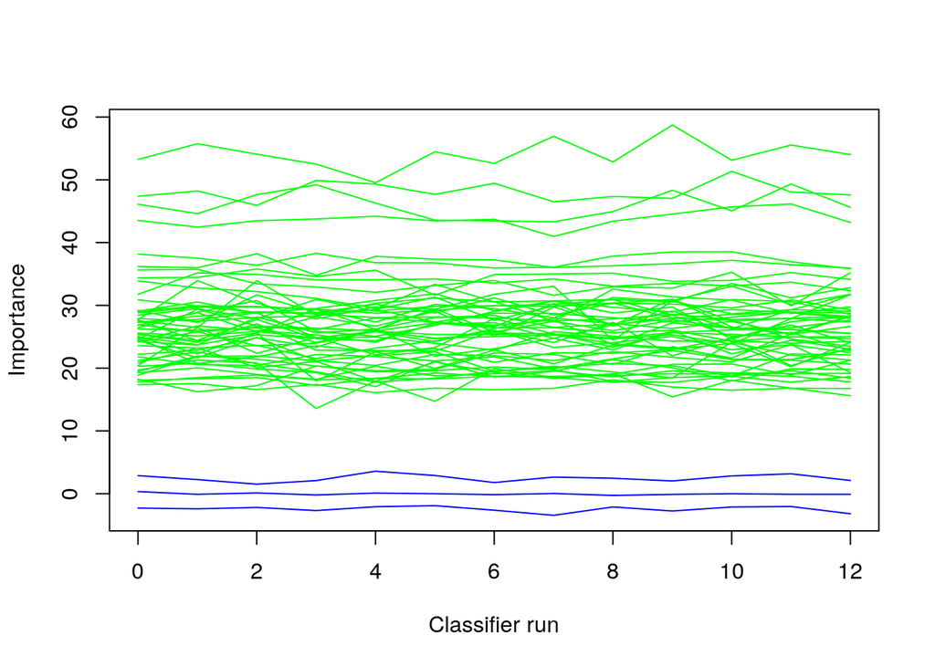

```r
set.seed(7779)
boruta<-Boruta(classe~., data=train, doTrace=2)
#plot(boruta, las=2, cex.axis=.7)
plotImpHistory(boruta)
```

It seems that all parameters left after NA cleaning are important.

### Model examination

Let’s run rpart model:

```r
set.seed(7779)
fit53RP<-train(classe~., data=train, method="rpart")
pred53RP<-predict(fit53RP, newdata=test)
cm<-confusionMatrix(pred53RP, test$classe)
cm$overall["Accuracy"]
```

```
##  Accuracy
## 0.5043331
```

Comment on low accuracy: Accuracy : 0.5043331 This level is not acceptable for the prediction.

Let’s run some of Random forest. We need to identify best ntree and mtry parameters:

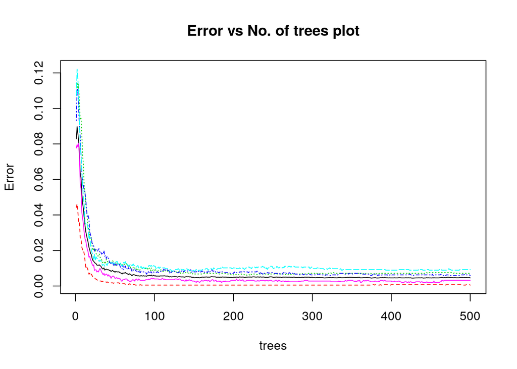

```r
set.seed(7779)
fit53RF<-randomForest(classe~., data=train)
plot(fit53RF, cex=0.7, main='Error vs No. of trees plot')
```

As per plot we can use ntree = 200, to identify best mtry I will run tuneRF:

```
## mtry = 7  OOB error = 0.48%
## Searching left ...
```

```
## mtry = 140   OOB error = 1.04%
## -1.166667 0.05
## Searching right ...
```

```
## mtry = 0     OOB error = 1.13%
## -1.348485 0.05
```

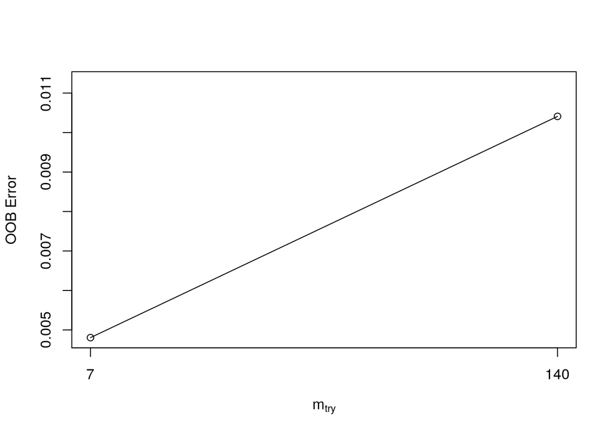

```
##         mtry    OOBError
## 0.OOB      0 0.011283395
## 7.OOB      7 0.004804542
## 140.OOB  140 0.010409842
```

```r
tuneRF(train[,-53], train$classe, stepFactor = 0.05, plot=T, ntreeTry=200, trace=T, improve=.05)
```

```r
fit53RF<-randomForest(formula = classe ~ ., data = train, ntree = 200,      mtry = 7, importance = F, proximity = F)
```

```r
fit33RF<- randomForest(formula =  classe ~ roll_belt + pitch_belt + yaw_belt + total_accel_belt +
    gyros_belt_x + gyros_belt_y + gyros_belt_z + accel_belt_x +
    accel_belt_y + accel_belt_z + magnet_belt_x + magnet_belt_y +
    magnet_belt_z + roll_arm + pitch_arm + yaw_arm + total_accel_arm +
    gyros_arm_x + gyros_arm_y + gyros_arm_z + accel_arm_x + accel_arm_y +
    accel_arm_z + magnet_arm_x + magnet_arm_y + magnet_arm_z +
    roll_dumbbell + pitch_dumbbell + yaw_dumbbell + total_accel_dumbbell +
    gyros_dumbbell_x + gyros_dumbbell_y + gyros_dumbbell_z,
    data = train, ntree = 200,      mtry = 7, importance = F, proximity = F)
```

## Test results

Let’s see predictions for all 3 models:

```r
cbind(as.data.frame(pred53ts), as.data.frame(pred33ts), as.data.frame(predRPts))
```

```
##    pred53ts pred33ts predRPts
## 1         B        B        A
## 2         A        A        A
## 3         B        B        C
## 4         A        A        C
## 5         A        A        B
## 6         E        E        C
## 7         D        D        C
## 8         B        B        C
## 9         A        A        A
## 10        A        A        A
## 11        B        B        A
## 12        C        C        C
## 13        B        B        B
## 14        A        A        A
## 15        E        E        C
## 16        E        E        B
## 17        A        A        A
## 18        B        B        A
## 19        B        B        A
## 20        B        B        B
```

Both RF models predicted same; Decision tree predicted well only A classe, all other classes are mixed.